# 산업공학특론I_13-14주차_산업데이터분석

2024-05-29

## [데이터 분석 개요]

### 1. 대상 데이터: 다단계 공정 데이터셋

(https://www.kaggle.com/datasets/supergus/multistage-continuousflow-manufacturing-process)

미시간 주 디트로이트 근처의 실제 생산 라인 내에서 여러 위치, 여러 생산 라인에 대하여 계측한 데이터

다양한 입력 데이터로부터 라인의 출력 특정 속성을 예측하기 위한 목적으로 수집

해당 공정 라인은 병렬 및 직렬 단계로 구성된 고속 연속 제조 공정으로, 다음과 같은 구조를 가짐

- Stage 1에서는 M1, M2, M3 기계가 병렬로 작동하며, 이들의 출력이 결합기로 전달
- 결합기에서 출력되는 Stage 1에 대한 예측치는 제작된 제품의 외부 표면을 둘러싼 15개의 위치에서 측정
- 다음으로, M4와 M5가 직렬로 처리하는 Stage 2로 이동
- M5 작동 후에는 동일한 15개의 위치에 대한 Stage 2의 측정이 이루어짐

* Oleghe, O. (2020). A predictive noise correction methodology for manufacturing process datasets. Journal of Big Data, 7(1), 89.

### 2. 분석 절차

데이터 탐색 및 전처리 / 특징 추출 및 차원 축소 / 모델 학습 및 평가 순서로 3단계로 나누어 분석 진행

2단계 공정인 관계로 Stage 1에 대한 예측모델, Stage 2에 대한 예측모델을 2단계로 모델링할 것 (이 때, Stage 2의 결과는 Stage 1에 영향을 받음)

원래 Stage 1, Stage 2에 대한 예측값은 각각 15개씩이지만, 본 강의에서는 다변량 예측을 다루지 않는 관계로 각 Stage에 대한 평균값을 종속변수로 설정

팀별로 작업을 수행하며, 작업 코드는 팀장의 Github에 Push하여 공유, 통찰력 있는 분석 기법 발굴 시 모두와 공유

가이드로 제공된 참고문헌을 바탕으로 다양한 방법론으로 분석을 수행

## [데이터 분석]

### 1. 데이터 탐색 및 전처리

- 데이터의 전반적인 분포, 특징을 파악하기 위한 기초 분석 진행
- 다양한 전처리 방법론을 활용하여 데이터를 정제 (e.g. 필요없는 변수 및 이상치/노이즈 제거 또는 보정, 표준화 등)
- 데이터 전처리 순서 (학습, 테스트셋 분할 전후)를 꼼꼼히 살펴보고 진행할 것

```r
trainsc1 <- read.csv("train_Stage1.csv"); trainsc2 <- read.csv("train_Stage2.csv")
testsc1 <- read.csv("test_Stage1.csv"); testsc2 <- read.csv("test_Stage2.csv")
```

### 2. 특징 추출 및 차원 축소

- 전처리가 이루어진 데이터로부터 특성을 재정의하거나 차원 축소 기법을 적용
- 신규 변수 또는 축소된 차원으로 효과적인 예측을 수행하기 위한 방안 도출

```r
library(pls)
library(caret)
library(Metrics)
```

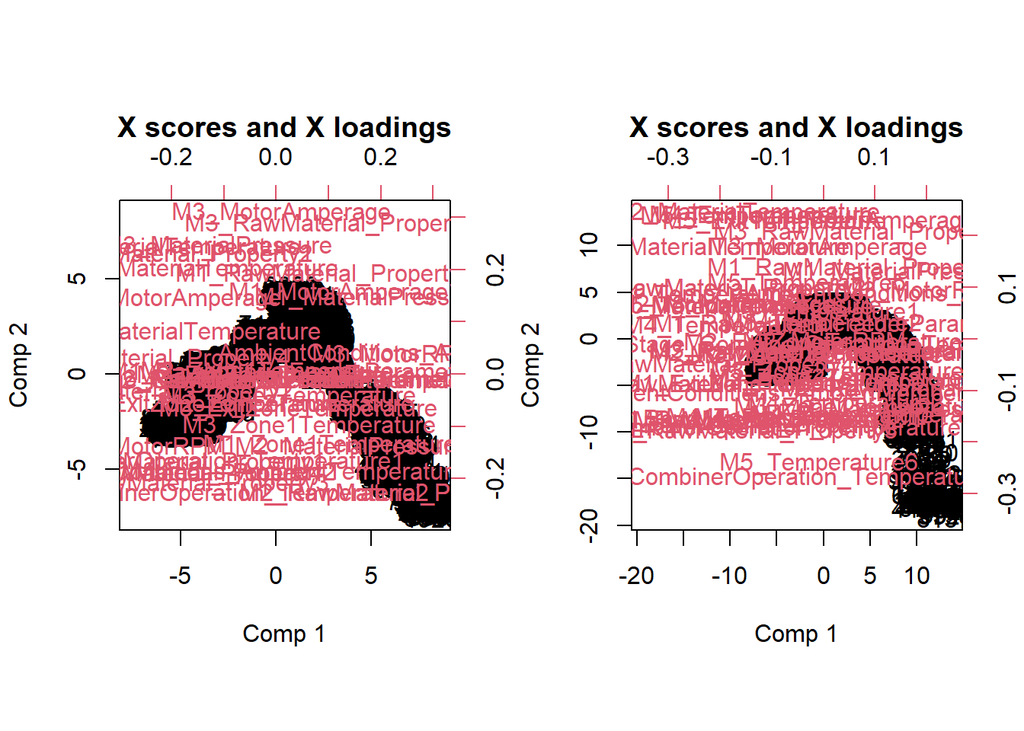

```r
err <- function(actual, pred) {
  result <- c(mae(actual, pred), mse(actual, pred), rmse(actual, pred))
  names(result) <- c('MAE', 'MSE', 'RMSE')
  print(result)
}

pcr_model1 <- pcr(trainsc1$Stage1_Output ~ ., data = trainsc1, validation = 'CV')
pcr_model2 <- pcr(trainsc2$Stage2_Output ~ ., data = trainsc2, validation = 'CV')
#주성분검토
par(mfrow=c(1,2))
biplot(pcr_model1); biplot(pcr_model2)
```

```r
summary(pcr_model1); summary(pcr_model2)
```

```
## Data:    X dimension: 9762 41
##  Y dimension: 9762 1
## Fit method: svdpc
## Number of components considered: 41
##
## VALIDATION: RMSEP
## Cross-validated using 10 random segments.
##        (Intercept)  1 comps  2 comps  3 comps  4 comps  5 comps  6 comps
## CV           1.167    1.104    1.104    1.084    1.082    1.061    1.061
## adjCV        1.167    1.104    1.104    1.084    1.082    1.061    1.061
##        7 comps  8 comps  9 comps  10 comps  11 comps  12 comps  13 comps
## CV        1.06    1.053    1.053     1.053     1.053     1.052     1.051
## adjCV     1.06    1.053    1.053     1.053     1.053     1.051     1.051
##        14 comps  15 comps  16 comps  17 comps  18 comps  19 comps  20 comps
## CV        1.050     1.048     1.046     1.046     1.047     1.036     1.037
## adjCV     1.049     1.048     1.046     1.046     1.047     1.036     1.037
##        21 comps  22 comps  23 comps  24 comps  25 comps  26 comps  27 comps
## CV        1.036     1.031      1.03     1.022     1.008     1.001         1
## adjCV     1.036     1.031      1.03     1.021     1.007     1.001         1
##        28 comps  29 comps  30 comps  31 comps  32 comps  33 comps  34 comps
## CV       0.9972    0.9709    0.9361    0.9135    0.9129    0.9103    0.9099
## adjCV    0.9970    0.9705    0.9358    0.9131    0.9127    0.9100    0.9096
##        35 comps  36 comps  37 comps  38 comps  39 comps  40 comps  41 comps
## CV       0.9087    0.9085    0.9085    0.9087    0.9088    0.9100    0.9156
## adjCV    0.9084    0.9081    0.9079    0.9073    0.9072    0.9076    0.9069
##
## TRAINING: % variance explained
##                         1 comps  2 comps  3 comps  4 comps  5 comps  6 comps
## X                         31.15    45.01     53.2    59.01    63.02    66.25
## trainsc1$Stage1_Output    10.61    10.69     13.8    14.30    17.54    17.57
##                         7 comps  8 comps  9 comps  10 comps  11 comps  12 comps
## X                         68.99     71.6    74.10     76.59     79.03     81.42
## trainsc1$Stage1_Output    17.86     18.9    18.99     19.00     19.01     19.21
##                         13 comps  14 comps  15 comps  16 comps  17 comps
## X                          83.66     85.81     87.81     89.74     91.38
## trainsc1$Stage1_Output     19.24     19.49     19.77     20.10     20.10
##                         18 comps  19 comps  20 comps  21 comps  22 comps
## X                           93.0     94.44     95.66     96.54     97.39
## trainsc1$Stage1_Output      20.1     21.63     21.64     21.77     22.66
##                         23 comps  24 comps  25 comps  26 comps  27 comps
## X                          98.02     98.41     98.80     99.15     99.37
## trainsc1$Stage1_Output     22.81     24.06     26.13     27.10     27.19
##                         28 comps  29 comps  30 comps  31 comps  32 comps
## X                          99.52     99.64     99.74     99.82     99.89
## trainsc1$Stage1_Output     27.68     31.87     36.46     39.47     39.54
##                         33 comps  34 comps  35 comps  36 comps  37 comps
## X                          99.94     99.97    100.00    100.00    100.00
## trainsc1$Stage1_Output     39.92     40.00     40.18     40.22     40.24
##                         38 comps  39 comps  40 comps  41 comps
## X                          100.0    100.00    100.00    100.00
## trainsc1$Stage1_Output      40.3     40.32     40.32     40.33
```

```
## Data:    X dimension: 9762 55
##  Y dimension: 9762 1
## Fit method: svdpc
## Number of components considered: 55
##
## VALIDATION: RMSEP
## Cross-validated using 10 random segments.
##        (Intercept)  1 comps  2 comps  3 comps  4 comps  5 comps  6 comps
## CV           1.475    1.463    1.062   0.9397   0.9283   0.9088   0.8967
## adjCV        1.475    1.463    1.061   0.9396   0.9282   0.9081   0.8967
##        7 comps  8 comps  9 comps  10 comps  11 comps  12 comps  13 comps
## CV      0.8929   0.8725   0.8640    0.8554    0.8524    0.8517    0.8518
## adjCV   0.8932   0.8719   0.8572    0.8549    0.8522    0.8515    0.8518
##        14 comps  15 comps  16 comps  17 comps  18 comps  19 comps  20 comps
## CV       0.8505    0.8493    0.8480    0.8283    0.8242     0.811    0.8101
## adjCV    0.8506    0.8494    0.8492    0.8283    0.8242     0.811    0.8099
##        21 comps  22 comps  23 comps  24 comps  25 comps  26 comps  27 comps
## CV       0.8058    0.8046    0.7927    0.7690    0.7686    0.7604    0.7572
## adjCV    0.8060    0.8048    0.7914    0.7689    0.7686    0.7603    0.7571
##        28 comps  29 comps  30 comps  31 comps  32 comps  33 comps  34 comps
## CV       0.7474    0.7366    0.7340    0.7339    0.7338    0.7339    0.7324
## adjCV    0.7473    0.7364    0.7338    0.7337    0.7336    0.7338    0.7323
##        35 comps  36 comps  37 comps  38 comps  39 comps  40 comps  41 comps
## CV       0.7321    0.7208    0.7209    0.7208    0.7165    0.7162    0.7159
## adjCV    0.7320    0.7206    0.7208    0.7207    0.7163    0.7160    0.7157
##        42 comps  43 comps  44 comps  45 comps  46 comps  47 comps  48 comps
## CV       0.7162    0.7131    0.7094    0.7093    0.6966    0.6961    0.6936
## adjCV    0.7160    0.7129    0.7092    0.7090    0.6962    0.6959    0.6934
##        49 comps  50 comps  51 comps  52 comps  53 comps  54 comps  55 comps
## CV       0.6917    0.6917    0.6918    0.6921    0.6921    0.6924    0.6933
## adjCV    0.6914    0.6914    0.6914    0.6916    0.6916    0.6915    0.6913
##
## TRAINING: % variance explained
##                         1 comps  2 comps  3 comps  4 comps  5 comps  6 comps
## X                        29.099    42.61    50.65    56.75    60.43    63.87
## trainsc2$Stage2_Output    1.817    48.32    59.51    60.50    62.20    63.11
##                         7 comps  8 comps  9 comps  10 comps  11 comps  12 comps
## X                         66.39    68.66    70.77     72.86     74.78     76.67
## trainsc2$Stage2_Output    63.45    65.19    66.41     66.50     66.74     66.81
##                         13 comps  14 comps  15 comps  16 comps  17 comps
```

[output cut: 11 more lines]

```
##                         33 comps  34 comps  35 comps  36 comps  37 comps
## X                          98.93     99.13     99.29     99.42     99.54
## trainsc2$Stage2_Output     75.44     75.57     75.61     76.34     76.35
##                         38 comps  39 comps  40 comps  41 comps  42 comps
## X                          99.62     99.71     99.77     99.83     99.88
## trainsc2$Stage2_Output     76.36     76.64     76.66     76.68     76.68
##                         43 comps  44 comps  45 comps  46 comps  47 comps
## X                          99.91     99.94     99.96     99.98     99.99
## trainsc2$Stage2_Output     76.89     77.14     77.15     77.99     78.01
##                         48 comps  49 comps  50 comps  51 comps  52 comps
## X                         100.00    100.00    100.00    100.00    100.00
## trainsc2$Stage2_Output     78.18     78.31     78.31     78.31     78.31
##                         53 comps  54 comps  55 comps
## X                         100.00    100.00    100.00
## trainsc2$Stage2_Output     78.31     78.31     78.31
```

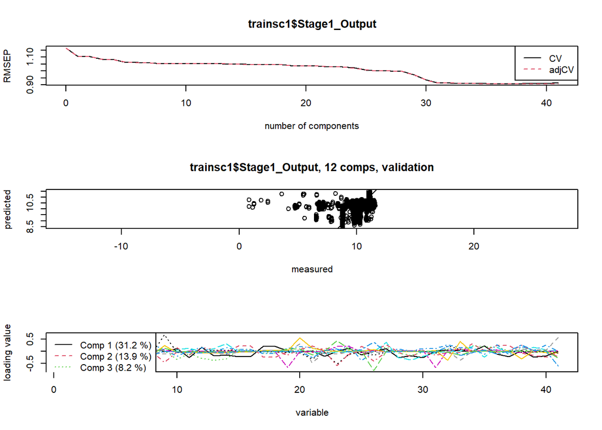

```r
par(mfrow=c(3,1))
plot(RMSEP(pcr_model1), legendpos = "topright")
plot(pcr_model1, ncomp = 12, asp = 1, line = TRUE)
plot(pcr_model1, "loadings", comps = 1:12, legendpos = "topleft")
```

```r
pc1 <- pcr_model1$scores[,1:12]
reg_pc1 <- lm(trainsc1$Stage1_Output ~ pc1)
summary(reg_pc1)
```

```
##
## Call:
## lm(formula = trainsc1$Stage1_Output ~ pc1)
##
## Residuals:
##     Min      1Q  Median      3Q     Max
## -9.7562 -0.3850  0.1271  0.7351  2.0572
##
## Coefficients:
##              Estimate Std. Error t value Pr(>|t|)
## (Intercept) 10.038015   0.010627 944.588  < 2e-16 ***
## pc1Comp 1    0.106407   0.002974  35.784  < 2e-16 ***
## pc1Comp 2    0.013786   0.004458   3.092  0.00199 **
## pc1Comp 3    0.112380   0.005801  19.373  < 2e-16 ***
## pc1Comp 4   -0.053243   0.006885  -7.734 1.15e-14 ***
## pc1Comp 5   -0.163931   0.008289 -19.776  < 2e-16 ***
## pc1Comp 6   -0.017946   0.009236  -1.943  0.05204 .
## pc1Comp 7    0.059004   0.010023   5.887 4.06e-09 ***
## pc1Comp 8    0.115344   0.010277  11.223  < 2e-16 ***
## pc1Comp 9   -0.034220   0.010487  -3.263  0.00111 **
## pc1Comp 10   0.014098   0.010526   1.339  0.18047
## pc1Comp 11   0.004836   0.010616   0.456  0.64876
## pc1Comp 12   0.053300   0.010756   4.956 7.34e-07 ***
## ---
## Signif. codes:  0 '***' 0.001 '**' 0.01 '*' 0.05 '.' 0.1 ' ' 1
##
## Residual standard error: 1.05 on 9749 degrees of freedom
## Multiple R-squared:  0.1921, Adjusted R-squared:  0.1911
## F-statistic: 193.2 on 12 and 9749 DF,  p-value: < 2.2e-16
```

```r
pred_pcr1 <- predict(pcr_model1, testsc1, ncomp=12)
err(testsc2$Stage2_Output, pred_pcr1)
```

```
##      MAE      MSE     RMSE
## 2.508940 8.497881 2.915113
```

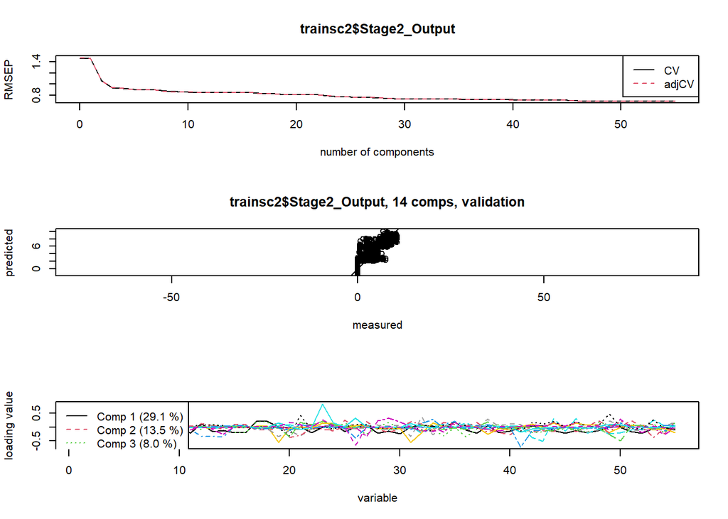

```r
par(mfrow=c(3,1))
plot(RMSEP(pcr_model2), legendpos = "topright")
plot(pcr_model2, ncomp = 14, asp = 1, line = TRUE)
plot(pcr_model2, "loadings", comps = 1:14, legendpos = "topleft")
```

```r
pc2 <- pcr_model1$scores[,1:14]
reg_pc2 <- lm(trainsc2$Stage2_Output ~ pc2)
summary(reg_pc2)
```

```
##
## Call:
## lm(formula = trainsc2$Stage2_Output ~ pc2)
##
## Residuals:
##     Min      1Q  Median      3Q     Max
## -6.6114 -0.3795 -0.0067  0.4345  4.1656
##
## Coefficients:
##              Estimate Std. Error  t value Pr(>|t|)
## (Intercept)  7.519599   0.008754  858.948  < 2e-16 ***
## pc2Comp 1   -0.009510   0.002450   -3.882 0.000104 ***
## pc2Comp 2    0.254480   0.003673   69.290  < 2e-16 ***
## pc2Comp 3   -0.132183   0.004779  -27.661  < 2e-16 ***
## pc2Comp 4   -0.595408   0.005672 -104.982  < 2e-16 ***
## pc2Comp 5   -0.152733   0.006829  -22.366  < 2e-16 ***
## pc2Comp 6   -0.067190   0.007609   -8.830  < 2e-16 ***
## pc2Comp 7    0.152217   0.008257   18.435  < 2e-16 ***
## pc2Comp 8    0.055958   0.008466    6.609 4.06e-11 ***
## pc2Comp 9   -0.010218   0.008639   -1.183 0.236956
## pc2Comp 10   0.004489   0.008671    0.518 0.604696
## pc2Comp 11   0.007733   0.008746    0.884 0.376615
## pc2Comp 12   0.155374   0.008860   17.536  < 2e-16 ***
## pc2Comp 13  -0.215826   0.009124  -23.654  < 2e-16 ***
## pc2Comp 14   0.135620   0.009323   14.547  < 2e-16 ***
## ---
## Signif. codes:  0 '***' 0.001 '**' 0.01 '*' 0.05 '.' 0.1 ' ' 1
##
## Residual standard error: 0.865 on 9747 degrees of freedom
## Multiple R-squared:  0.6567, Adjusted R-squared:  0.6562
## F-statistic:  1332 on 14 and 9747 DF,  p-value: < 2.2e-16
```

```r
pred_pcr2 <- predict(pcr_model2, testsc2, ncomp=14)
err(testsc2$Stage2_Output, pred_pcr2)
```

```
##       MAE       MSE      RMSE
## 0.5661763 0.7031227 0.8385241
```

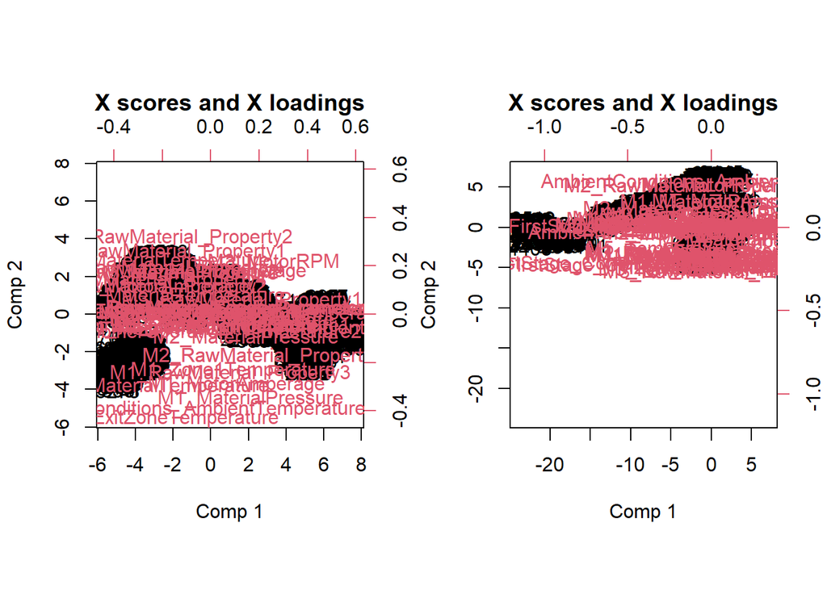

```r
# PLSR
# 모델수립
plsr_model1 <- plsr(trainsc1$Stage1_Output ~ ., data = trainsc1, validation = 'CV')
plsr_model2 <- plsr(trainsc2$Stage2_Output ~ ., data = trainsc2, validation = 'CV')
#잠재변수검토
par(mfrow=c(1,2))
biplot(plsr_model1); biplot(plsr_model2)
```

```r
summary(plsr_model1); summary(plsr_model2)
```

```
## Data:    X dimension: 9762 41
##  Y dimension: 9762 1
## Fit method: kernelpls
## Number of components considered: 41
##
## VALIDATION: RMSEP
## Cross-validated using 10 random segments.
##        (Intercept)  1 comps  2 comps  3 comps  4 comps  5 comps  6 comps
## CV           1.167    1.083    1.039    1.017    1.005   0.9822   0.9603
## adjCV        1.167    1.083    1.039    1.016    1.005   0.9818   0.9601
##        7 comps  8 comps  9 comps  10 comps  11 comps  12 comps  13 comps
## CV      0.9445   0.9311   0.9186    0.9131    0.9102    0.9092    0.9089
## adjCV   0.9443   0.9308   0.9183    0.9128    0.9100    0.9090    0.9087
##        14 comps  15 comps  16 comps  17 comps  18 comps  19 comps  20 comps
## CV       0.9081    0.9079    0.9077    0.9077    0.9077    0.9075    0.9074
## adjCV    0.9079    0.9077    0.9074    0.9074    0.9074    0.9073    0.9072
##        21 comps  22 comps  23 comps  24 comps  25 comps  26 comps  27 comps
## CV       0.9075    0.9074    0.9074    0.9074    0.9074    0.9074    0.9074
## adjCV    0.9072    0.9072    0.9072    0.9071    0.9071    0.9072    0.9071
##        28 comps  29 comps  30 comps  31 comps  32 comps  33 comps  34 comps
## CV       0.9074    0.9073    0.9073    0.9073    0.9073    0.9073    0.9072
## adjCV    0.9071    0.9071    0.9071    0.9070    0.9071    0.9070    0.9070
##        35 comps  36 comps  37 comps  38 comps  39 comps  40 comps  41 comps
## CV       0.9072    0.9072    0.9072    0.9072    0.9072    0.9072    0.9072
## adjCV    0.9070    0.9070    0.9069    0.9069    0.9069    0.9069    0.9069
##
## TRAINING: % variance explained
##                         1 comps  2 comps  3 comps  4 comps  5 comps  6 comps
## X                         30.45    37.88    44.14    54.53    58.60    61.96
## trainsc1$Stage1_Output    13.99    21.19    24.72    26.50    29.98    33.00
##                         7 comps  8 comps  9 comps  10 comps  11 comps  12 comps
## X                         65.30    67.12    68.41     70.06     71.93     73.73
## trainsc1$Stage1_Output    35.16    37.04    38.64     39.45     39.79     39.93
##                         13 comps  14 comps  15 comps  16 comps  17 comps
## X                          75.82     76.70     78.51     79.46     81.21
## trainsc1$Stage1_Output     39.96     40.06     40.09     40.13     40.14
##                         18 comps  19 comps  20 comps  21 comps  22 comps
## X                          82.25     83.36     85.07     85.93     87.54
## trainsc1$Stage1_Output     40.16     40.17     40.17     40.18     40.18
##                         23 comps  24 comps  25 comps  26 comps  27 comps
## X                          88.50     89.59     90.94     92.52     93.22
## trainsc1$Stage1_Output     40.19     40.19     40.19     40.19     40.19
##                         28 comps  29 comps  30 comps  31 comps  32 comps
## X                          95.21     95.43      97.4     98.28     99.74
## trainsc1$Stage1_Output     40.19     40.20      40.2     40.20     40.20
##                         33 comps  34 comps  35 comps  36 comps  37 comps
## X                          99.82     99.90     99.96    100.00    100.62
## trainsc1$Stage1_Output     40.22     40.22     40.22     40.22     40.22
##                         38 comps  39 comps  40 comps  41 comps
## X                         101.23    101.85    102.47    103.09
## trainsc1$Stage1_Output     40.22     40.22     40.22     40.22
```

```
## Data:    X dimension: 9762 55
##  Y dimension: 9762 1
## Fit method: kernelpls
## Number of components considered: 55
##
## VALIDATION: RMSEP
## Cross-validated using 10 random segments.
##        (Intercept)  1 comps  2 comps  3 comps  4 comps  5 comps  6 comps
## CV           1.475   0.9377   0.8713   0.8031   0.7533   0.7376   0.7305
## adjCV        1.475   0.9376   0.8713   0.8031   0.7532   0.7375   0.7304
##        7 comps  8 comps  9 comps  10 comps  11 comps  12 comps  13 comps
## CV      0.7236   0.7178   0.7147    0.7107    0.7079    0.7062    0.7043
## adjCV   0.7235   0.7176   0.7146    0.7107    0.7077    0.7060    0.7041
##        14 comps  15 comps  16 comps  17 comps  18 comps  19 comps  20 comps
## CV       0.7026    0.6998    0.6979    0.6969    0.6963    0.6956    0.6952
## adjCV    0.7023    0.6996    0.6977    0.6967    0.6961    0.6953    0.6949
##        21 comps  22 comps  23 comps  24 comps  25 comps  26 comps  27 comps
## CV       0.6949    0.6946    0.6943    0.6940    0.6941    0.6938    0.6936
## adjCV    0.6946    0.6943    0.6940    0.6938    0.6938    0.6936    0.6934
##        28 comps  29 comps  30 comps  31 comps  32 comps  33 comps  34 comps
## CV       0.6935    0.6933    0.6932    0.6930    0.6928    0.6925    0.6924
## adjCV    0.6932    0.6931    0.6930    0.6928    0.6926    0.6924    0.6922
##        35 comps  36 comps  37 comps  38 comps  39 comps  40 comps  41 comps
## CV       0.6923    0.6922    0.6921    0.6920    0.6920    0.6919    0.6919
## adjCV    0.6921    0.6920    0.6919    0.6918    0.6917    0.6917    0.6916
##        42 comps  43 comps  44 comps  45 comps  46 comps  47 comps  48 comps
## CV       0.6919    0.6918    0.6915    0.6915    0.6915    0.6915    0.6915
## adjCV    0.6916    0.6916    0.6913    0.6913    0.6913    0.6913    0.6913
##        49 comps  50 comps  51 comps  52 comps  53 comps  54 comps  55 comps
## CV       0.6915    0.6915    0.6915    0.6915    0.6915    0.6915    0.6915
## adjCV    0.6913    0.6913    0.6913    0.6913    0.6913    0.6913    0.6913
##
## TRAINING: % variance explained
##                         1 comps  2 comps  3 comps  4 comps  5 comps  6 comps
## X                         15.27    40.22    48.57    52.79    56.36    60.52
## trainsc2$Stage2_Output    59.66    65.18    70.48    74.09    75.19    75.69
##                         7 comps  8 comps  9 comps  10 comps  11 comps  12 comps
## X                         63.00    64.50    66.61     68.57     69.91     71.51
## trainsc2$Stage2_Output    76.15    76.54    76.77     77.01     77.23     77.35
##                         13 comps  14 comps  15 comps  16 comps  17 comps
```

[output cut: 11 more lines]

```
##                         33 comps  34 comps  35 comps  36 comps  37 comps
## X                          93.51     94.06     95.37     95.88     97.25
## trainsc2$Stage2_Output     78.23     78.25     78.26     78.27     78.27
##                         38 comps  39 comps  40 comps  41 comps  42 comps
## X                          98.16     99.10     99.33     99.41     99.62
## trainsc2$Stage2_Output     78.27     78.28     78.28     78.29     78.29
##                         43 comps  44 comps  45 comps  46 comps  47 comps
## X                          99.74     99.77     99.84     99.90     99.94
## trainsc2$Stage2_Output     78.29     78.31     78.31     78.31     78.31
##                         48 comps  49 comps  50 comps  51 comps  52 comps
## X                          99.98    100.00    100.10    100.20    100.30
## trainsc2$Stage2_Output     78.31     78.31     78.31     78.31     78.31
##                         53 comps  54 comps  55 comps
## X                         100.40    100.50    100.60
## trainsc2$Stage2_Output     78.31     78.31     78.31
```

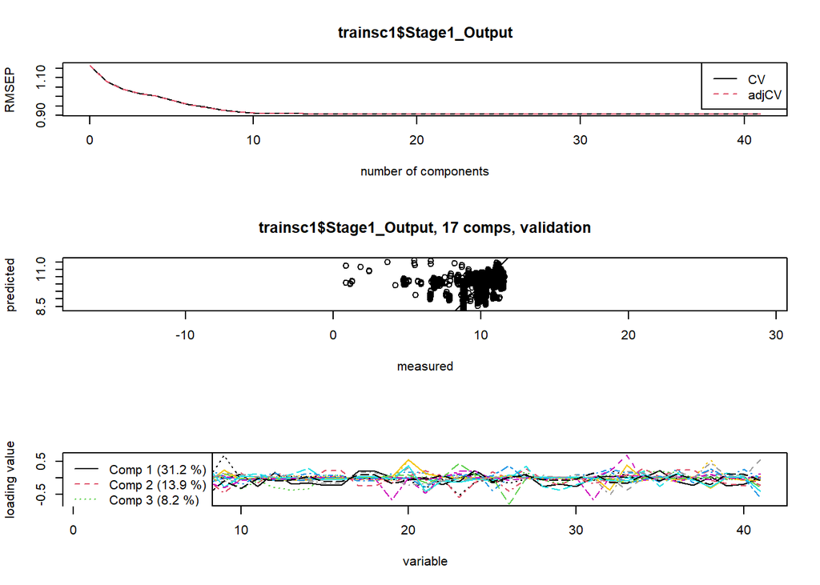

```r
par(mfrow=c(3,1))
plot(RMSEP(plsr_model1), legendpos = "topright")
plot(pcr_model1, ncomp = 17, asp = 1, line = TRUE)
plot(pcr_model1, "loadings", comps = 1:17, legendpos = "topleft")
```

```r
pred_plsr1 <- predict(plsr_model1, testsc1, ncomp=17)
err(testsc2$Stage2_Output, pred_plsr1)
```

```
##      MAE      MSE     RMSE
## 2.538998 8.602329 2.932973
```

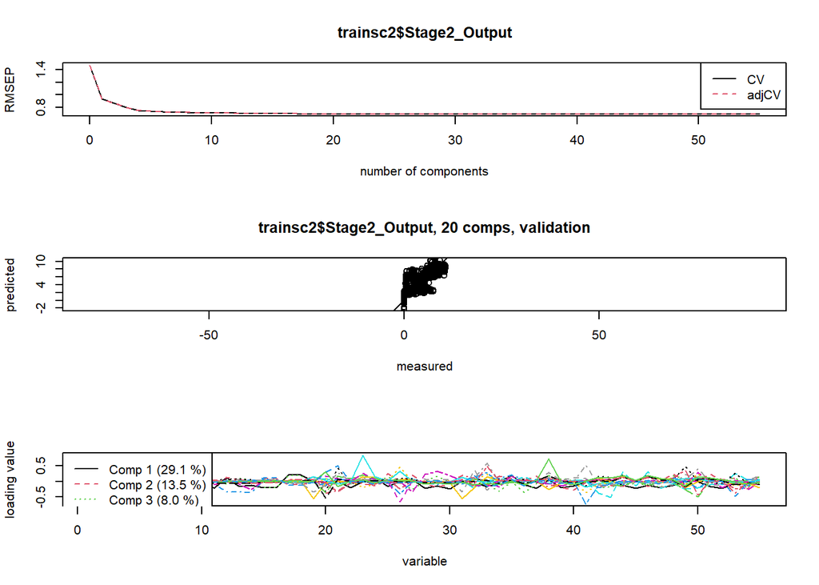

```r
par(mfrow=c(3,1))
plot(RMSEP(plsr_model2), legendpos = "topright")
plot(pcr_model2, ncomp = 20, asp = 1, line = TRUE)
plot(pcr_model2, "loadings", comps = 1:20, legendpos = "topleft")
```

```r
pred_plsr2 <- predict(plsr_model2, testsc2, ncomp=20)
err(testsc2$Stage2_Output, pred_plsr2)
```

```
##       MAE       MSE      RMSE
## 0.4031246 0.4458105 0.6676904
```

### 3. 모델 학습 및 평가

- Stage 1, Stage 2에 대한 예측 모델을 수립할 것
- 이 때, 각 Stage는 연결되어 있으며 Stage 2는 Stage 1의 영향을 받음

```r
library(randomForest)
set.seed(2024)
rf_model_stage1 <- randomForest(Stage1_Output ~ ., data = trainsc1, importance = TRUE, ntree = 100)
summary(rf_model_stage1)
```

```
##                 Length Class  Mode
## call               5   -none- call
## type               1   -none- character
## predicted       9762   -none- numeric
## mse              100   -none- numeric
## rsq              100   -none- numeric
## oob.times       9762   -none- numeric
## importance        82   -none- numeric
## importanceSD      41   -none- numeric
## localImportance    0   -none- NULL
## proximity          0   -none- NULL
## ntree              1   -none- numeric
## mtry               1   -none- numeric
## forest            11   -none- list
## coefs              0   -none- NULL
## y               9762   -none- numeric
## test               0   -none- NULL
## inbag              0   -none- NULL
## terms              3   terms  call
```

```r
# Predict Stage 1 output for test data
pred_stage1 <- predict(rf_model_stage1, newdata = testsc1)
err(testsc1$Stage1_Output, pred_stage1)
```

```
##       MAE       MSE      RMSE
## 0.3098478 0.2586406 0.5085672
```

```r
# Add predicted Stage 1 output to the training data for Stage 2
trainsc2$Pred_Stage1_Output <- predict(rf_model_stage1, newdata = trainsc2)

# Fit Random Forest model for Stage 2
set.seed(2024)
rf_model_stage2 <- randomForest(Stage2_Output ~ . + Pred_Stage1_Output, data = trainsc2, importance = TRUE, ntree = 100)
summary(rf_model_stage2)
```

```
##                 Length Class  Mode
## call               5   -none- call
## type               1   -none- character
## predicted       9762   -none- numeric
## mse              100   -none- numeric
## rsq              100   -none- numeric
## oob.times       9762   -none- numeric
## importance       112   -none- numeric
## importanceSD      56   -none- numeric
## localImportance    0   -none- NULL
## proximity          0   -none- NULL
## ntree              1   -none- numeric
## mtry               1   -none- numeric
## forest            11   -none- list
## coefs              0   -none- NULL
## y               9762   -none- numeric
## test               0   -none- NULL
## inbag              0   -none- NULL
## terms              3   terms  call
```

```r
# Predict Stage 2 output for test data (including predicted Stage 1 output)
testsc2$Pred_Stage1_Output <- pred_stage1
pred_stage2 <- predict(rf_model_stage2, newdata = testsc2)
err(testsc2$Stage2_Output, pred_stage2)
```

```
##       MAE       MSE      RMSE
## 0.2543895 0.2390184 0.4888951
```

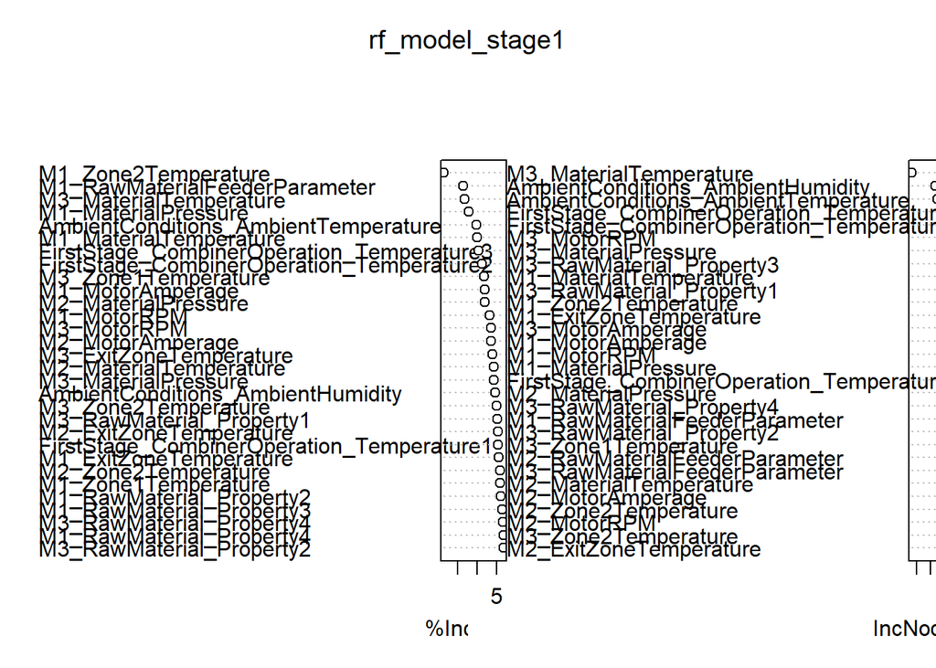

```r
# Visualize variable importance for Stage 1
varImpPlot(rf_model_stage1)
```

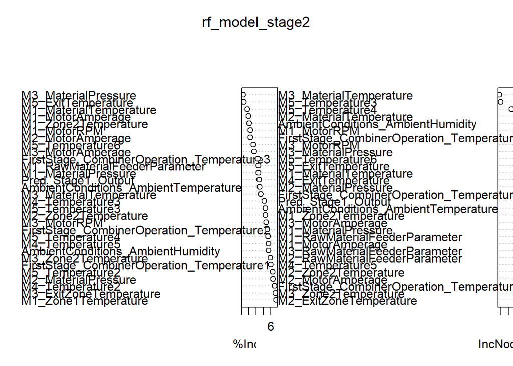

```r
# Visualize variable importance for Stage 2
varImpPlot(rf_model_stage2)
```